# **Deep Learning Project: Street View Housing Number Digit Recognition**

## **Context**

The SVHN dataset contains over 600,000 labeled digits cropped from street-level photos. It is one of the most popular image recognition datasets. It has been used in neural networks created by Google to improve the map quality by automatically transcribing the address numbers from a patch of pixels. The transcribed number with a known street address helps pinpoint the location of the building it represents.

## **Objective**

Our objective is to predict the number depicted inside the image by using Artificial or Fully Connected Feed Forward Neural Networks and Convolutional Neural Networks. We will go through various models of each and finally select the one that is giving us the best performance.

## **Dataset**

Here, we will use a subset of the original data to save some computation time. The dataset is provided as a .h5 file. The basic preprocessing steps have been applied on the dataset.

Let us start by mounting the Google drive. You can run the below cell to mount the Google drive.

```python
from google.colab import drive
drive.mount('/content/drive')
```

## **Importing the necessary libraries**

```python
import numpy as np
import pandas as pd
import matplotlib.pyplot as plt
from sklearn.model_selection import train_test_split
from sklearn.preprocessing import MinMaxScaler
import tensorflow as tf
from tensorflow.keras.models import Sequential
from tensorflow.keras.layers import Dense, Dropout, Activation, BatchNormalization, Flatten, Conv2D, MaxPooling2D, LeakyReLU
from tensorflow.keras.losses import categorical_crossentropy
from tensorflow.keras.optimizers import Adam
from tensorflow.keras.utils import to_categorical
```

**Let us check the version of tensorflow.**

```python
print(tf.__version__)
```

```
2.14.0
```

## **Load the dataset**

- Let us now load the dataset that is available as a .h5 file.
- Split the data into the train and the test dataset.

```python
# Importing h5py library
import h5py

# Using context manager "with statement" to open the file, which ensures it gets closed when finished
with h5py.File('/content/drive/MyDrive/SVHN_single_grey1.h5', 'r') as h5f:
    # Print the shape of each dataset
    for name in ['X_train', 'y_train', 'X_test', 'y_test']:
        print(name, h5f[name].shape)
```

```
X_train (42000, 32, 32)
y_train (42000,)
X_test (18000, 32, 32)
y_test (18000,)
```

Dataset has a large number of images, but only 32x32 pixels and monochromatic. It is safe to assume that we can load the entire dataset in a single batch.

```python
# Using context manager "with statement" to open the file, which ensures it gets closed when finished
with h5py.File('/content/drive/MyDrive/Useful Docs/Courses/MIT Applied Data Science/Week 8 - Elective Project/SVHN_single_grey1.h5', 'r') as h5f:
  # Loading entire train and test datasets in a single batch
  X_train = h5f['X_train'][:]
  y_train = h5f['y_train'][:]
  X_test = h5f['X_test'][:]
  y_test = h5f['y_test'][:]
```

Check the number of images in the training and the testing dataset.

```python
# Making sure loaded data is as expected and checking the size of datasets
X_train.shape, y_train.shape, X_test.shape, y_test.shape
```

```
((42000, 32, 32), (42000,), (18000, 32, 32), (18000,))
```

```python
# Print the size of datasets
print("The training dataset has {} images, and test dataset has {} images.".format(len(X_train), len(X_test)))
```

```
The training dataset has 42000 images, and test dataset has 18000 images.
```

**Observation: The dataset is composed of 42000 training images and 18000 test images. Although the number of images is large, they are only 32x32 pixels and monochromatic, which has given me confidence to open it in a single batch.**

## **Visualizing images**

- Use X_train to visualize the first 10 images.
- Use Y_train to print the first 10 labels.

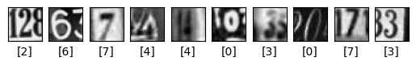

```python
# Visualizing first 10 images in the training dataset and printing their labels
for i in range(10):
    plt.subplot(1, 10, i+1)
    plt.xticks([])
    plt.yticks([])
    plt.grid(False)
    plt.imshow(X_train[i], cmap = plt.cm.binary)
    plt.xlabel([y_train[i]])
plt.show()
```

**Observation: It can be seen in the plots that the dataset contains some quite challenging images even to the human eye.**

## **Data preparation**

Printing the shape and the array of pixels for the first image in training dataset.

```python
# Shape and the array of pixels for the first image
print("Shape:", X_train[0].shape)
print("First image:\n", X_train[0])
```

```
Shape: (32, 32)
First image:
 [[ 33.0704  30.2601  26.852  ...  71.4471  58.2204  42.9939]
 [ 25.2283  25.5533  29.9765 ... 113.0209 103.3639  84.2949]
 [ 26.2775  22.6137  40.4763 ... 113.3028 121.775  115.4228]
 ...
 [ 28.5502  36.212   45.0801 ...  24.1359  25.0927  26.0603]
 [ 38.4352  26.4733  23.2717 ...  28.1094  29.4683  30.0661]
 [ 50.2984  26.0773  24.0389 ...  49.6682  50.853   53.0377]]
```

### **Normalize the train and the test data**

```python
# Normalize to [0, 1]
X_train = X_train.astype('float32') / 255
X_test = X_test.astype('float32') / 255
```

Print the shapes of Training and Test data

```python
# Flattening the 2D images to 1D for ANN evaluation
X_train_ann = X_train.reshape(X_train.shape[0], 1024)
X_test_ann = X_test.reshape(X_test.shape[0], 1024)

# Reshaping the 2D dataset to a 4D array as input to CNNs (X,Y pixels, greyscale and colour channels)
X_train_cnn = X_train.reshape(X_train.shape[0], 32, 32, 1)
X_test_cnn = X_test.reshape(X_test.shape[0], 32, 32, 1)

# Printing new shape of training and test datasets for ANN evaluation
print("New shape of ANN train dataset", X_train_ann.shape)
print("New shape of ANN test dataset", X_test_ann.shape)
print("New shape of CNN train dataset", X_train_cnn.shape)
print("New shape of CNN test dataset", X_test_cnn.shape)
print("The labels remain the same")
```

```
New shape of ANN train dataset (42000, 1024)
New shape of ANN test dataset (18000, 1024)
New shape of CNN train dataset (42000, 32, 32, 1)
New shape of CNN test dataset (18000, 32, 32, 1)
The labels remain the same
```

### **One-hot encode output**

```python
# One-hot encoded vectors for the target variable
y_train = tf.keras.utils.to_categorical(y_train, num_classes=10)
y_test = tf.keras.utils.to_categorical(y_test, num_classes=10)
print("New shape of one-hot encoded labels", y_train.shape)
print("New shape of one-hot encoded test labels", y_test.shape)
```

```
New shape of one-hot encoded labels (42000, 10)
New shape of one-hot encoded test labels (18000, 10)
```

**Observation: In this step, the dataset has been normalised, reshaped and one-hot encoded. The dataset has been normalised first in order to save some computation when reshaping the data for ANN evaluation and CNN evaluation. They require different data formats as their inputs, ANNs require a flat 1D layer and CNNs take in a 4D input.**

- New shape of ANN train dataset (42000, 1024)
- New shape of ANN test dataset (18000, 1024)
- New shape of CNN train dataset (42000, 32, 32, 1)
- New shape of CNN test dataset (18000, 32, 32, 1)
- New shape of one-hot encoded labels (42000, 10)
- New shape of one-hot encoded test labels (18000, 10)

## **Model Building**

```python
# Fixing the seed for random number generators
fixed_seed = 42

#Creating a function as we'll be resetting the seed multiple times throughou the notebook
def reset_seed(seed):
  np.random.seed(seed)
  import random
  random.seed(seed)
  tf.random.set_seed(seed)
  print("Random number generators seed has been set to", seed)
reset_seed(fixed_seed)
```

```
Random number generators seed has been set to 42
```

### **Build and train an ANN model.**

```python
# Define the model

def nn_model_1():
    model = Sequential()
    # First hidden layer with 64 nodes and the relu activation and the input shape = (1024, )
    model.add(Dense(64, activation = 'relu', input_shape = (1024,)))
    # Second hidden layer with 32 nodes and the relu activation
    model.add(Dense(32, activation = 'relu'))
    # Output layer with activation as 'softmax' and number of nodes equal to the number of classes, i.e., 10
    model.add(Dense(10, activation = 'softmax'))

    # Compile the model with the loss equal to categorical_crossentropy, optimizer equal
    # to Adam(learning_rate = 0.001), and metric equal to 'accuracy'.
    model.compile(optimizer=Adam(learning_rate = 0.001),
                  loss='categorical_crossentropy',
                  metrics=['accuracy'])
    # Do not fit the model here, just return the compiled model.
    return model
```

Call the nn_model_1 function and store the model in a new variable.

```python
# Build the model
model_1 = nn_model_1()
```

```python
# Print the summary
model_1.summary()
```

```
Model: "sequential"
_________________________________________________________________
 Layer (type)                Output Shape              Param #
=================================================================
 dense (Dense)               (None, 64)                65600

 dense_1 (Dense)             (None, 32)                2080

 dense_2 (Dense)             (None, 10)                330

=================================================================
Total params: 68010 (265.66 KB)
Trainable params: 68010 (265.66 KB)
Non-trainable params: 0 (0.00 Byte)
_________________________________________________________________
```

```python
# Clearing backend
from tensorflow.keras import backend
backend.clear_session()

reset_seed(fixed_seed)
```

```
Random number generators seed has been set to 42
```

```python
  # Fitting the model with required parameters above, saving model into history_1 variable
  history_1 = model_1.fit(
              X_train_ann, y_train,
              validation_split = 0.2,
              batch_size = 128,
              epochs = 20,
              verbose = 1
  )
```

The training and validation accuracies are both about 67%.

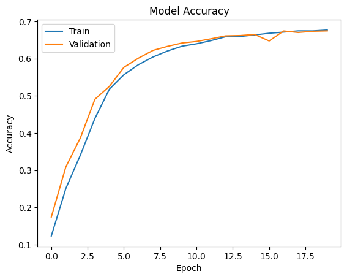

```python
# Plotting the Training and Validation accuracies
plt.plot(history_1.history['accuracy'])
plt.plot(history_1.history['val_accuracy'])
plt.title('Model Accuracy')
plt.ylabel('Accuracy')
plt.xlabel('Epoch')
plt.legend(['Train', 'Validation'], loc = 'upper left')

# Display the plot
plt.show()
```

Evaluating model on test dataset

```python
# Evaluate the model on the test data
test_loss, test_accuracy = model_1.evaluate(X_test_ann, y_test, verbose=1)

# Print the results
print("Test Loss:", test_loss)
print("Test Accuracy:", test_accuracy)
```

```
Test Loss: 1.045327067375183
Test Accuracy: 0.6780555844306946
```

### **Observations: The training, validation and test datasets have performed very similarly, resulting in about 67% accuracy. The Model Accuracy plot reveals that perhaps the model could achieve a better accuracy if trained for a few more epochs.**

Let's build one more model with higher complexity and see if we can improve the performance of the model.

```python
# Clearing backend
backend.clear_session()

# Reset seed for number generators using reset_seed() function
reset_seed(fixed_seed)
```

```
Random number generators seed has been set to 42
```

Creating more complex model

```python
# Define the model

def nn_complex_model_1():
    model = Sequential()
    # First hidden layer with 64 nodes and the relu activation and the input shape = (1024, )
    model.add(Dense(64, activation = 'relu', input_shape = (1024,)))
    # Second hidden layer with 32 nodes and the relu activation
    model.add(Dense(32, activation = 'relu'))
    # Third hidden layer with 32 nodes and the relu activation
    model.add(Dense(32, activation = 'relu'))
    # Output layer with activation as 'softmax' and number of nodes equal to the number of classes, i.e., 10
    model.add(Dense(10, activation = 'softmax'))

    # Compile the model with the loss equal to categorical_crossentropy, optimizer equal
    # to Adam(learning_rate = 0.001), and metric equal to 'accuracy'.
    model.compile(optimizer=Adam(learning_rate = 0.001),
                  loss='categorical_crossentropy',
                  metrics=['accuracy'])
    # Do not fit the model here, just return the compiled model.
    return model

# Build the model
model_1_complex = nn_complex_model_1()
```

Printing new more complex model summary

```python
# Print the summary
model_1_complex.summary()
```

```
Model: "sequential"
_________________________________________________________________
 Layer (type)                Output Shape              Param #
=================================================================
 dense (Dense)               (None, 64)                65600

 dense_1 (Dense)             (None, 32)                2080

 dense_2 (Dense)             (None, 32)                1056

 dense_3 (Dense)             (None, 10)                330

=================================================================
Total params: 69066 (269.79 KB)
Trainable params: 69066 (269.79 KB)
Non-trainable params: 0 (0.00 Byte)
_________________________________________________________________
```

Fitting new more complex model

```python
# Fitting the model with required parameters above
history_complex_1 = model_1_complex.fit(
            X_train_ann, y_train,
            validation_split = 0.2,
            batch_size = 128,
            epochs = 30,
            verbose = 1
)
```

```python
# Evaluate the model on the test data
test_loss_complex, test_accuracy_complex = model_1_complex.evaluate(X_test_ann, y_test, verbose=1)

# Print the results
print("Test Loss:", test_loss_complex)
print("Test Accuracy:", test_accuracy_complex)
```

```
Test Loss: 0.9612053036689758
Test Accuracy: 0.7064444422721863
```

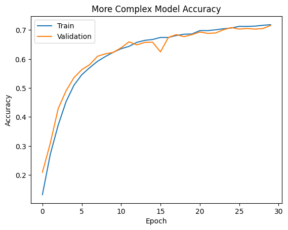

```python
# Plotting the Training and Validation accuracies of new more complex model
plt.plot(history_complex_1.history['accuracy'])
plt.plot(history_complex_1.history['val_accuracy'])
plt.title('More Complex Model Accuracy')
plt.ylabel('Accuracy')
plt.xlabel('Epoch')
plt.legend(['Train', 'Validation'], loc = 'upper left')

# Display the plot
plt.show()
```

### **Observations: A more complex model with an additional hidden layer has given a marginal improvement at 20 epochs, but proven to be more accurate than the initial model when trained to epoch 30. On training, validation and test datasets the accuracy of the new more complex model is of about 71% versus 68% when trained for 20 epochs.**

### **Build and train the new ANN model**

```python
# Clearing backend
backend.clear_session()

# Reset seed for number generators using reset_seed() function
reset_seed(fixed_seed)

# Define the second model as per requirements:

def nn_model_2():
    model = Sequential()

    #First hidden layer with 256 nodes and the relu activation and the input shape = (1024, )
    model.add(Dense(256, activation = 'relu', input_shape = (1024,)))
    #Second hidden layer with 128 nodes and the relu activation
    model.add(Dense(128, activation = 'relu'))
    #Add the Dropout layer with the rate equal to 0.2
    model.add(Dropout(0.2))
    #Third hidden layer with 64 nodes and the relu activation
    model.add(Dense(64, activation = 'relu'))
    #Fourth hidden layer with 64 nodes and the relu activation
    model.add(Dense(64, activation = 'relu'))
    #Fifth hidden layer with 32 nodes and the relu activation
    model.add(Dense(32, activation = 'relu'))
    #Add the BatchNormalization layer
    model.add(BatchNormalization())
    #Output layer with activation as 'softmax' and number of nodes equal to the number of classes, i.e., 10
    model.add(Dense(10, activation = 'softmax'))
    #Compile the model with the loss equal to categorical_crossentropy, optimizer equal to Adam(learning_rate = 0.0005),
    #and metric equal to 'accuracy'. Do not fit the model here, just return the compiled model.
    model.compile(optimizer=Adam(learning_rate = 0.0005),
                  loss='categorical_crossentropy',
                  metrics=['accuracy'])
    # Do not fit the model here, just return the compiled model.
    return model
```

```
Random number generators seed has been set to 42
```

Call the nn_model_2 function and store the model in a new variable.

```python
# Build the model
model_2 = nn_model_2()
```

```python
# Print the summary
model_2.summary()
```

```
Model: "sequential"
_________________________________________________________________
 Layer (type)                Output Shape              Param #
=================================================================
 dense (Dense)               (None, 256)               262400

 dense_1 (Dense)             (None, 128)               32896

 dropout (Dropout)           (None, 128)               0

 dense_2 (Dense)             (None, 64)                8256

 dense_3 (Dense)             (None, 64)                4160

 dense_4 (Dense)             (None, 32)                2080

 batch_normalization (Batch  (None, 32)                128
 Normalization)

 dense_5 (Dense)             (None, 10)                330

=================================================================
Total params: 310250 (1.18 MB)
Trainable params: 310186 (1.18 MB)
Non-trainable params: 64 (256.00 Byte)
_________________________________________________________________
```

```python
# Fitting the model with required parameters above
history_2 = model_2.fit(
            X_train_ann, y_train,
            validation_split = 0.2,
            batch_size = 128,
            epochs = 30,
            verbose = 1
)
```

[figure not shown]

```python
# Plotting the Training and Validation accuracies of new model
plt.plot(history_2.history['accuracy'])
plt.plot(history_2.history['val_accuracy'])
plt.title('New ANN Model Accuracy')
plt.ylabel('Accuracy')
plt.xlabel('Epoch')
plt.legend(['Train', 'Validation'], loc = 'upper left')

# Display the plot
plt.show()
```

Evaluating the model on test data

```python
# Evaluate the model on the test data
test_loss_model2, test_accuracy_model2 = model_2.evaluate(X_test_ann, y_test, verbose=1)

# Print the results
print("Test Loss:", test_loss_model2)
print("Test Accuracy:", test_accuracy_model2)
```

```
Test Loss: 0.7927138805389404
Test Accuracy: 0.7523888945579529
```

## **Observations: The accuracy values of training, validation and test datasets have performed very similarly in the new ANN model, ranging around 74% accuracy. The Model Accuracy plot reveals that perhaps the model could perhaps achieve a better accuracy if trained for a few more epochs.**

## **Predictions on the test data**

```python
# Making predictions on test dataset using the second model
test_pred = model_2.predict(X_test_ann)
test_pred_classes = np.argmax(test_pred, axis = -1)
```

**Note:** Earlier, we noticed that each entry of the target variable is a one-hot encoded vector but to print the classification report and confusion matrix, we must convert each entry of y_test to a single label.

```python
# Converting one-hot encoded y_test back to an int
y_test_labels = np.argmax(y_test, axis = -1)
```

Print the obtained results using the classification report and the confusion matrix.

```python
# Importing relevant libraries
from sklearn.metrics import classification_report
from sklearn.metrics import confusion_matrix
import seaborn as sns

# Creating function to plot confusion matrix
def metrics_score(actual, predicted):

    print(classification_report(actual, predicted))

    cm = confusion_matrix(actual, predicted)

    plt.figure(figsize = (8, 5))

    sns.heatmap(cm, annot = True,  fmt = '.0f')

    plt.ylabel('Actual')

    plt.xlabel('Predicted')

    plt.show()
```

[output not shown]

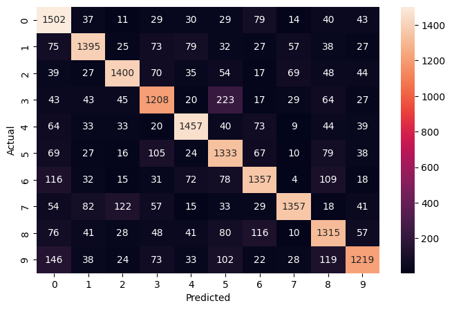

```python
# Plotting confusion matrix for predicted classes
metrics_score(y_test_labels, test_pred_classes)
```

## **Final Observations:**

**Suggestions:**

- **The Model Accuracy plot reveals that perhaps the model could achieve a better accuracy if trained for a few more epochs.**
- **Providing more training data is also likely to improve the accuracy of the model.**

## **Using Convolutional Neural Networks**

```python
# Using context manager "with statement" to open the file, which ensures it gets closed when finished
with h5py.File('/content/drive/MyDrive/Useful Docs/Courses/MIT Applied Data Science/Week 8 - Elective Project/SVHN_single_grey1.h5', 'r') as h5f:
  # Loading entire train and test datasets in a single batch
  X_train = h5f['X_train'][:]
  y_train = h5f['y_train'][:]
  X_test = h5f['X_test'][:]
  y_test = h5f['y_test'][:]
  for name in ['X_train', 'y_train', 'X_test', 'y_test']:
      print(name, h5f[name].shape)
```

```
X_train (42000, 32, 32)
y_train (42000,)
X_test (18000, 32, 32)
y_test (18000,)
```

Check the number of images in the training and the testing dataset.

```python
# Print the size of datasets
print("The training dataset has {} images, and test dataset has {} images.".format(len(X_train), len(X_test)))
```

```
The training dataset has 42000 images, and test dataset has 18000 images.
```

## **Data preparation**

```python
# Print the shape and the array of pixels for the first image in the training dataset.
print("Shape:", X_train[0].shape)
print("First image:\n", X_train[0])
```

```
Shape: (32, 32)
First image:
 [[ 33.0704  30.2601  26.852  ...  71.4471  58.2204  42.9939]
 [ 25.2283  25.5533  29.9765 ... 113.0209 103.3639  84.2949]
 [ 26.2775  22.6137  40.4763 ... 113.3028 121.775  115.4228]
 ...
 [ 28.5502  36.212   45.0801 ...  24.1359  25.0927  26.0603]
 [ 38.4352  26.4733  23.2717 ...  28.1094  29.4683  30.0661]
 [ 50.2984  26.0773  24.0389 ...  49.6682  50.853   53.0377]]
```

Reshape the dataset to be able to pass them to CNNs.

```python
# Reshaping the 2D dataset to a 4D array as input to CNNs (X,Y pixels, greyscale and colour channels)
X_train_cnn = X_train.reshape(X_train.shape[0], 32, 32, 1)
X_test_cnn = X_test.reshape(X_test.shape[0], 32, 32, 1)
```

Normalize inputs from 0-255 to 0-1

```python
# Normalize to [0, 1]
X_train_cnn = X_train_cnn.astype('float32') / 255
X_test_cnn = X_test_cnn.astype('float32') / 255
```

Print New shape of Training and Test

```python
# Printing new shape of training and test datasets for ANN evaluation
print("New shape of CNN train dataset", X_train_cnn.shape)
print("New shape of CNN test dataset", X_test_cnn.shape)
```

```
New shape of CNN train dataset (42000, 32, 32, 1)
New shape of CNN test dataset (18000, 32, 32, 1)
```

### **One-hot encode the labels in the target variable y_train and y_test.**

```python
# One-hot encoded vectors for the target variable
y_train = tf.keras.utils.to_categorical(y_train, num_classes=10)
y_test = tf.keras.utils.to_categorical(y_test, num_classes=10)
print("New shape of one-hot encoded labels", y_train.shape)
print("New shape of one-hot encoded test labels", y_test.shape)
```

```
New shape of one-hot encoded labels (42000, 10)
New shape of one-hot encoded test labels (18000, 10)
```

**Observation: In this step, the dataset has been normalised, reshaped and one-hot encoded as requested. It was not necessary since these steps were already done at the start of the notebook. The new formats are as follows**

- New 4D shape of CNN train dataset (42000, 32, 32, 1)
- New 4D shape of CNN test dataset (18000, 32, 32, 1)
- New shape of one-hot encoded labels (42000, 10)
- New shape of one-hot encoded test labels (18000, 10)

## **Model Building**

```python
# Clearing backend
backend.clear_session()

# Reset seed for number generators using reset_seed() function
reset_seed(fixed_seed)
```

```
Random number generators seed has been set to 42
```

### **Build and train a CNN model as per the above mentioned architecture.**

```python
# Define the CNN model as per requirements:

def cnn_model_1():
    cnn_model = Sequential()

    # First Convolutional layer with 16 filters and the kernel size of 3x3. Use the 'same' padding and provide the input shape = (32, 32, 1)
    cnn_model.add(Conv2D(filters = 16, kernel_size = (3, 3), padding = "same", input_shape = (32, 32, 1)))
    # Add a LeakyRelu layer with the slope equal to 0.1
    cnn_model.add(LeakyReLU(0.1))
    # Second Convolutional layer with 32 filters and the kernel size of 3x3 with 'same' padding
    cnn_model.add(Conv2D(filters = 32, kernel_size = (3, 3), padding = "same"))
    # Another LeakyRelu with the slope equal to 0.1
    cnn_model.add(LeakyReLU(0.1))
    # A max-pooling layer with a pool size of 2x2
    cnn_model.add(MaxPooling2D(pool_size = (2, 2)))
    # Flatten the output from the previous layer
    cnn_model.add(Flatten())
    # Add a dense layer with 32 nodes
    cnn_model.add(Dense(32))
    # Add a LeakyRelu layer with the slope equal to 0.1
    cnn_model.add(LeakyReLU(0.1))
    # Add the final output layer with nodes equal to the number of classes, i.e., 10 and 'softmax' as the activation function
    cnn_model.add(Dense(10, activation = 'softmax'))
    # Compile the model with the loss equal to categorical_crossentropy, optimizer equal to Adam(learning_rate = 0.001),
    # and metric equal to 'accuracy'. Do not fit the model here, just return the compiled model.
    cnn_model.compile(loss='categorical_crossentropy',
              optimizer=Adam(learning_rate = 0.001),
              metrics=['accuracy'])
    return cnn_model
```

Call the function cnn_model_1 and store the output in a new variable.

```python
# Call the function cnn_model_1 and store the output in a new variable.
cnn_model_1 = cnn_model_1()
```

```python
# Print the summary of the model.
cnn_model_1.summary()
```

```
Model: "sequential"
_________________________________________________________________
 Layer (type)                Output Shape              Param #
=================================================================
 conv2d (Conv2D)             (None, 32, 32, 16)        160

 leaky_re_lu (LeakyReLU)     (None, 32, 32, 16)        0

 conv2d_1 (Conv2D)           (None, 32, 32, 32)        4640

 leaky_re_lu_1 (LeakyReLU)   (None, 32, 32, 32)        0

 max_pooling2d (MaxPooling2  (None, 16, 16, 32)        0
 D)

 flatten (Flatten)           (None, 8192)              0

 dense (Dense)               (None, 32)                262176

 leaky_re_lu_2 (LeakyReLU)   (None, 32)                0

 dense_1 (Dense)             (None, 10)                330

=================================================================
Total params: 267306 (1.02 MB)
Trainable params: 267306 (1.02 MB)
Non-trainable params: 0 (0.00 Byte)
_________________________________________________________________
```

```python
# Fit the model on the training data with a validation split of 0.2, batch size = 32, verbose = 1, and epochs = 20.
# Store the model building history to use later for visualization.
cnn_history_1 = cnn_model_1.fit(
            X_train_cnn, y_train,
            validation_split = 0.2,
            batch_size = 32,
            epochs = 20,
            verbose = 1
)
```

### **Plot the Training and Validation Accuracies**

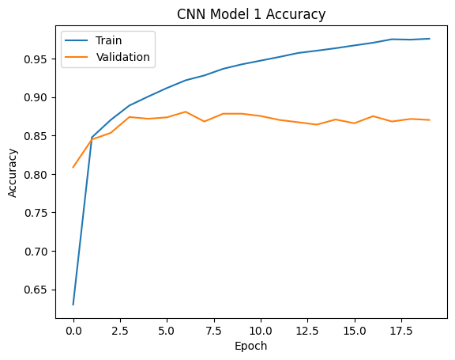

```python
# Plotting the Training and Validation accuracies of CNN model 1
plt.plot(cnn_history_1.history['accuracy'])
plt.plot(cnn_history_1.history['val_accuracy'])
plt.title('CNN Model 1 Accuracy')
plt.ylabel('Accuracy')
plt.xlabel('Epoch')
plt.legend(['Train', 'Validation'], loc = 'upper left')

# Display the plot
plt.show()
```

### Observation: Validation accuracy seems to plateau after epochs 5 or 6, and training the model further does not seem to improve its accuracy with new data.

Evaluating CNN model in test data

```python
# Evaluate CNN model 1 on the test data
test_loss_cnn1, test_accuracy_cnn1 = cnn_model_1.evaluate(X_test_cnn, y_test, verbose=1)
```

```python
# Print the results
print("Test Loss:", test_loss_cnn1)
print("Test Accuracy:", test_accuracy_cnn1)
```

```
Test Loss: 0.8330382704734802
Test Accuracy: 0.8689444661140442
```

### **Observations: As expected the CNN model is significantly more complex and computationally intensive than the ANN model, it took orders of magnitude longer to train than the ANN model. The complexity of the model does not seems to be benefiting it, since there are signs of overfitting, where there are significant discrepancies between training accuracy and validation/test accuracy:**

- Training Accuracy: around 97%
- Validation and Test Accuracy: Lower around 87%

### **We shoud improve generalisation of the model in order to avoid overfitting.**

Let's build another model and see if we can get a better model with generalized performance.

First, we need to clear the previous model's history from the Keras backend. Also, let's fix the seed again after clearing the backend.

```python
# Clearing backend
backend.clear_session()

# Reset seed for number generators using reset_seed() function
reset_seed(fixed_seed)
```

```
Random number generators seed has been set to 42
```

### **Second Model Architecture**

### **Build and train the second CNN model with generalisation layers**

```python
# Define the CNN model as per requirements:

def cnn_model_2():
    cnn_model = Sequential()

    # First Convolutional layer with 16 filters and the kernel size of 3x3. Use the 'same' padding and provide the input shape = (32, 32, 1)
    cnn_model.add(Conv2D(filters = 16, kernel_size = (3, 3), padding = "same", input_shape = (32, 32, 1)))
    # Add a LeakyRelu layer with the slope equal to 0.1
    cnn_model.add(LeakyReLU(0.1))
    # Second Convolutional layer with 32 filters and the kernel size of 3x3 with 'same' padding
    cnn_model.add(Conv2D(filters = 32, kernel_size = (3, 3), padding = "same"))
    # Another LeakyRelu with the slope equal to 0.1
    cnn_model.add(LeakyReLU(0.1))
    # A max-pooling layer with a pool size of 2x2
    cnn_model.add(MaxPooling2D(pool_size = (2, 2)))
    # Add a BatchNormalization layer
    cnn_model.add(BatchNormalization())
    # Third Convolutional layer with 32 filters and the kernel size of 3x3 with 'same' padding
    cnn_model.add(Conv2D(filters = 32, kernel_size = (3, 3), padding = "same"))
    # Add a LeakyRelu layer with the slope equal to 0.1
    cnn_model.add(LeakyReLU(0.1))
    # Fourth Convolutional layer 64 filters and the kernel size of 3x3 with 'same' padding
    cnn_model.add(Conv2D(filters = 32, kernel_size = (3, 3), padding = "same"))
    # Add a LeakyRelu layer with the slope equal to 0.1
    cnn_model.add(LeakyReLU(0.1))
    # Add a max-pooling layer with a pool size of 2x2
    cnn_model.add(MaxPooling2D(pool_size = (2, 2)))
    # Add a BatchNormalization layer
    cnn_model.add(BatchNormalization())
    # Flatten the output from the previous layer
    cnn_model.add(Flatten())
    # Add a dense layer with 32 nodes
    cnn_model.add(Dense(32))
    # Add a LeakyRelu layer with the slope equal to 0.1
    cnn_model.add(LeakyReLU(0.1))
    # Add a dropout layer with the rate equal to 0.5
    cnn_model.add(Dropout(0.5))
    # Add the final output layer with nodes equal to the number of classes, i.e., 10 and 'softmax' as the activation function
    cnn_model.add(Dense(10, activation = 'softmax'))
    # Compile the model with the categorical_crossentropy loss, adam optimizers (learning_rate = 0.001),
    # and metric equal to 'accuracy'. Do not fit the model here, just return the compiled model.
    cnn_model.compile(loss='categorical_crossentropy',
              optimizer=Adam(learning_rate = 0.001),
              metrics=['accuracy'])
    return cnn_model
```

Call the function cnn_model_2 and store the model in a new variable.

```python
# Call the function cnn_model_1 and store the output in a new variable.
cnn_model_2 = cnn_model_2()
```

```python
# Print model summary
cnn_model_2.summary()
```

```
Model: "sequential_2"
_________________________________________________________________
 Layer (type)                Output Shape              Param #
=================================================================
 conv2d_8 (Conv2D)           (None, 32, 32, 16)        160

 leaky_re_lu_10 (LeakyReLU)  (None, 32, 32, 16)        0

 conv2d_9 (Conv2D)           (None, 32, 32, 32)        4640

 leaky_re_lu_11 (LeakyReLU)  (None, 32, 32, 32)        0

 max_pooling2d_4 (MaxPoolin  (None, 16, 16, 32)        0
 g2D)

 batch_normalization_4 (Bat  (None, 16, 16, 32)        128
 chNormalization)

 conv2d_10 (Conv2D)          (None, 16, 16, 32)        9248

 leaky_re_lu_12 (LeakyReLU)  (None, 16, 16, 32)        0

 conv2d_11 (Conv2D)          (None, 16, 16, 32)        9248

 leaky_re_lu_13 (LeakyReLU)  (None, 16, 16, 32)        0

 max_pooling2d_5 (MaxPoolin  (None, 8, 8, 32)          0
 g2D)

 batch_normalization_5 (Bat  (None, 8, 8, 32)          128
 chNormalization)

 flatten_2 (Flatten)         (None, 2048)              0

 dense_3 (Dense)             (None, 32)                65568

 leaky_re_lu_14 (LeakyReLU)  (None, 32)                0

 dropout_2 (Dropout)         (None, 32)                0

 dense_4 (Dense)             (None, 10)                330

=================================================================
Total params: 89450 (349.41 KB)
Trainable params: 89322 (348.91 KB)
Non-trainable params: 128 (512.00 Byte)
_________________________________________________________________
```

```python
# Fit the model on the training data with a validation split of 0.2, batch size = 32, verbose = 1, and epochs = 20.
# Store the model building history to use later for visualization.
cnn_history_2 = cnn_model_2.fit(
            X_train_cnn, y_train,
            validation_split = 0.2,
            batch_size = 32,
            epochs = 20,
            verbose = 1
)
```

### **Plot the Training and Validation accuracies.**

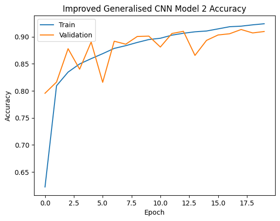

```python
# Plotting the Training and Validation accuracies of CNN model 1
plt.plot(cnn_history_2.history['accuracy'])
plt.plot(cnn_history_2.history['val_accuracy'])
plt.title('Improved Generalised CNN Model 2 Accuracy')
plt.ylabel('Accuracy')
plt.xlabel('Epoch')
plt.legend(['Train', 'Validation'], loc = 'upper left')

# Display the plot
plt.show()
```

Testing more generalised CNN model 2 on test data

```python
# Evaluate CNN model 1 on the test data
test_loss_cnn2, test_accuracy_cnn2 = cnn_model_2.evaluate(X_test_cnn, y_test, verbose=1)

# Print the results
print("Test Loss:", test_loss_cnn2)
print("Test Accuracy:", test_accuracy_cnn2)
```

```
Test Loss: 0.36198151111602783
Test Accuracy: 0.9086111187934875
```

**Observations: The new CNN model using generalisation techniques such as Batch Normalisation, Dropout and MaxPooling has mitigated overfitting, but at the cost of extra about 10 minutes of computing time. The final accuracy is:**

- Training accuracy: About 92%
- Validation and Test accuracy: About 91%

**The accuracy difference between training and validation/test has reduced significantly with this new CNN model with extra layers for generalisation.**

## **Predictions on the test data**

```python
# Making predictions on test dataset using the second model
cnn_test_pred = cnn_model_2.predict(X_test_cnn)
cnn_test_pred_classes = np.argmax(cnn_test_pred, axis = -1)
```

**Note:** Earlier, we noticed that each entry of the target variable is a one-hot encoded vector, but to print the classification report and confusion matrix, we must convert each entry of y_test to a single label.

```python
# Converting one-hot encoded y_test back to an int
y_test_labels = np.argmax(y_test, axis = -1)
```

[output not shown]

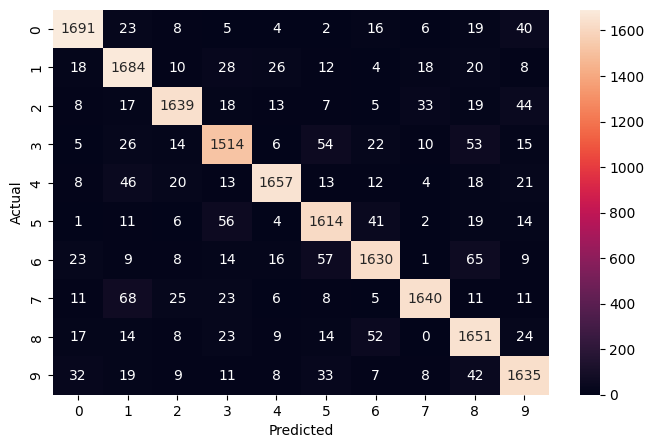

```python
# Plotting confusion matrix for predicted classes with more generalised CNN model
metrics_score(y_test_labels, cnn_test_pred_classes)
```

### Final Observations: The more generalised CNN model has significantly improved accuracy whilst mitigating overfitting. The confusion matrix diagonal of the more complex CNN model also reveals that the model performs much more uniformly when compared to the more complex ANN model tested in this workbook.

### It can't be discarded however, that a more accurate and complex CNN does come at a very significant cost in processing time and extra steps required to avoid overfitting.

### Although the more complex CNN model does a much better job in terms of accuracy, it is still possible to observe in the confusion matrix that it is still getting some predictions wrong for digits that are visually similar, just like in simpler ANN models used in this workbook. For example:

- **The number 3 and numbers 8 or 5.**
- **The number 7 and number 1.**

### **Suggestions:**

- **If the accuracy of this model is still not sufficient for its application, it would perhaps benefit from more training examples of the numbers with lower accuracy, such as number 3.**
- **If more training data is available in the future, perhaps a simpler model would be sufficient for the application.**
- **Training a simpler model for a few more epochs and feeding more data, could potentially result in a similar performance but at a much lower computational cost.**

### **Conclusion: If there are computational restrictions, there is potential to improve the ANN model if more training data is provided and if it could be trained for a few more epochs. If computation is not an issue, deploying a CNN model is recommended due to its significantly improved accuracy.**